# What a Margin of Error Does and Does Not Cover

Everything that goes wrong outside the sampling

Democracy’s Data

Last updated September 13, 2026 at 10:53a EDT

A poll says a candidate has 51%, with a margin of error of three points — a statement of how far off the estimate could be and still be doing its job. The election arrives and the candidate gets 46. Everyone says the poll was wrong. Was it? The answer turns on what that ± actually promised, and the promise is narrower than almost anyone who reads it knows.

The question is not academic. 5 states in 2024, carrying 64 electoral votes between them, were decided by less than the ±3.10 points a standard poll of a thousand people advertises as its own precision. The electoral college that year was 312 to 226; those 64 votes were more than enough to reverse it. The races that decide American elections sit inside the error bar of the instrument used to describe them. So: what does the margin of error cover — and are the errors that have actually been moving polls the covered kind?

## The test

You cannot watch a poll fail unless you already know the right answer. Political polls are the one opinion measure that eventually gets graded by a real event, the election itself. That separates this brief from the rest of its section: the surveys chapter explains what a sample can establish that no record can, and nothing ever grades those answers. But even for political polls the grade arrives too late to help. By the time the election settles the question, the population has changed, and the poll cannot be re-run against it.

So the test here is a **simulation**: a country built on purpose, inside a computer, whose true answer is known because we chose it. Construct a population of 1,000,000 voters split at a fixed, known number, then poll it thousands of times — honestly, and then with exactly one thing going wrong. Holding the truth fixed and varying one thing is the only way to separate the error a poll advertises from the error that has been going wrong. No archive of real polls can do it, however large.

One real table anchors the exercise: the 2024 presidential result in every state, from a compilation by the researcher Jay Timm, published on GitHub and downloadable by anyone, of the fifty-one official state counts. It sets the scale of what a poll is asked to resolve. The random draws are fixed, so the figures do not change from one reading to the next, and the central result is checked against algebra rather than against a lucky draw.

## The data

The real table is `pres2024_states.csv`: 51 rows, one per state plus Washington DC. Its columns are `state`, `abbrev`, `ev` (electoral votes), `harris`, `trump` and `other` (percentages of the vote), `winner`, and `margin` (Trump minus Harris, in points). It was cut from Timm’s *PresElectionResults* compilation, which holds every presidential election back to 1864 in one file, `pres_by_state.rda`, and every difference between the two is a decision.

Only 2024 is kept. The compilation’s party columns, `democrat` and `republican`, are renamed here to the candidates, `harris` and `trump`, which is right for 2024 and nonsense for any other year. Electoral votes are not in the source at all; they were typed in from the 2020 apportionment — the division of House seats among the states after the 2020 census, since a state’s electoral votes are its seats plus its two senators — and checked against 538.[^1] And the source carries percentages, not vote counts, so nothing here can be summed to a national total.

That last fact forces the one exception to this book’s rule that every number is computed. **The simulated country’s split is typed, not derived**, because the file kept here holds nothing to add up. Harris takes 49.25% of the two-party vote and Trump 50.75%, a constant chosen to sit near the 2024 national result. The population built from it has no missing values and nobody else’s decisions inside it — which is exactly why it cannot stand in for a real electorate.

| Candidate | Voters | Share |
| --- | --- | --- |
| Harris | 492,500 | 49.25 |
| Trump | 507,500 | 50.75 |

The second invented number is the **response gap**: in the biased polls below, Harris voters are 20% likelier to answer than Trump voters. Twenty percent is a plausible-looking number, not a measured one. The shape of what it does transfers to the real world; the size of it transfers nowhere.

Here is what the real table says a poll would have had to resolve — every state whose result came in tighter than the ±3.10 a poll of 1,000 advertises:

| State | Electoral votes | Harris (%) | Trump (%) | Margin (Trump − Harris) | Winner |
| --- | --- | --- | --- | --- | --- |
| Wisconsin | 10 | 48.74 | 49.60 | 0.86 | Trump |
| Michigan | 15 | 48.31 | 49.73 | 1.42 | Trump |
| Pennsylvania | 19 | 48.66 | 50.37 | 1.71 | Trump |
| Georgia | 16 | 48.53 | 50.73 | 2.20 | Trump |
| New Hampshire | 4 | 50.65 | 47.87 | -2.78 | Harris |

> **Before you read on, commit to a number.** A poll of 1,000 people advertises a margin of error of ±3.10 points; a poll of 100,000 people advertises ±0.31, a claim of near-certainty. The **response rate** of a telephone poll, the share of people dialled who complete the interview, has collapsed: Pew Research Center’s own surveys got answers from 36% of the numbers they called in 1997 and 6% in 2018.[^2] Suppose the people who pick up are not a random slice — suppose Harris voters are 20% likelier to answer. **How far off will the poll of 100,000 people be?** Write down a number of points before you read on.

## What it says about democracy

One simulated poll works like this. Pick 1,000 of the 1,000,000 voters at random — every voter equally likely, the way names drawn from a hat would be — ask each one which candidate they support, which the computer already knows, and report Harris’s share of the 1,000. Since 49.25% of the country is for Harris, each person drawn has that chance of being a Harris voter, and the share among a thousand of them will land near 49.25 but almost never on it. Poll the built country that way three times:

| Poll | Estimate of Harris’s share (%) | Truth (%) |
| --- | --- | --- |
| 1 | 50.90 | 49.25 |
| 2 | 52.10 | 49.25 |
| 3 | 48.20 | 49.25 |

Three honest polls, three different answers. That wobble is **sampling error**, the error that comes from asking 1,000 people instead of everyone, and it is the only kind of error the ± describes. Now run a thousand honest polls and pile up their answers in a histogram — the **sampling distribution**, the spread of results that polls of one size produce from one country — and beside them a thousand polls drawn from a pool where Harris voters are 20% likelier to pick up the phone.

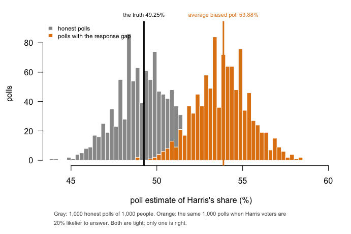

**Figure 1. A thousand honest polls, and the same thousand polls with a response gap.** Two histograms, because the question is about the spread of many polls, not any single one. Gray: honest polls, centered on the truth at 49.25%. Orange: the same polls when Harris voters are 20% likelier to answer, centered on 53.88%. **Both distributions are equally tight.** Only one is in the right place, and nothing about the width of either says which.

| Quantity | Value |
| --- | --- |
| Margin of error claimed at n = 1,000 | ±3.10 points |
| Polls landing inside it | 94.5% |
| Average of the thousand polls | 49.27% |
| The truth | 49.25% |

Bigger samples buy more of the same promise:

| People polled | Margin of error (points) |
| --- | --- |
| 500 | ±4.38 |
| 1,000 | ±3.10 |
| 5,000 | ±1.39 |
| 20,000 | ±0.69 |
| 100,000 | ±0.31 |

Precision improves with the square root of the sample, so a hundredfold increase buys a tenfold improvement. Now grade the biased polls against it:

| People polled | Estimate (%) | Advertised margin | Actually wrong by | As a multiple of its own margin |
| --- | --- | --- | --- | --- |
| 1,000 | 54.00 | ±3.10 | +4.75 | 1.5× |
| 10,000 | 54.63 | ±0.98 | +5.38 | 5.5× |
| 100,000 | 53.68 | ±0.31 | +4.43 | 14.3× |

Most readers write down something smaller than the ±3 they started with, reasoning that a poll a hundred times larger cannot be worse than a small one. Instead, **a poll of 100,000 people reports a margin of ±0.31 points and misses by 4.43** — about 14 times its own stated precision. And it does not drift toward the truth as the sample grows. It converges on 53.80%, which is not the answer.

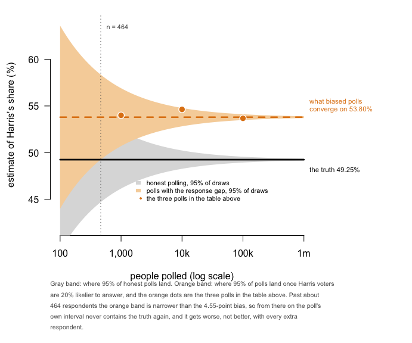

Gray band: where 95% of honest polls land. Orange band: where 95% of polls land once Harris voters are 20% likelier to answer, and the orange dots are the three polls in the table above. Past about 464 respondents the orange band is narrower than the 4.55-point bias, so from there on the poll’s own interval never contains the truth again, and it gets worse, not better, with every extra respondent.

**Figure 2. Where polls land, as the sample grows.** The gray band is where 95% of honest polls fall; the orange band is where 95% fall under the response gap, with the three polls from the table as dots. Both bands narrow at the same rate, but only one narrows onto the truth. Past about 464 respondents the orange band is narrower than the 4.55-point bias, so from there on **the poll’s own interval never contains the truth again**, and it gets worse with every extra respondent.

That convergence point is algebra, not a draw: if Harris voters answer 20% more readily, the responding pool is 53.80% Harris no matter how many of them you talk to. **More data makes you more confident about the wrong number.** The tight orange cluster is not evidence of accuracy but of agreement, and every poll in it agrees on a figure 4.55 points from the truth. Averaging them changes nothing, because they are all wrong in the same direction. That is exactly what a polling average does, and why its narrow interval does not mean what readers take it to mean.

How big does the gap have to be before it matters? Smaller than intuition says:

| Response gap | Bias (points) | Advertised margin at n = 1,000 | As a multiple of the simulated election margin |
| --- | --- | --- | --- |
| 2% | +0.50 | ±3.10 | 0.3 |
| 5% | +1.22 | ±3.10 | 0.8 |
| 10% | +2.38 | ±3.10 | 1.6 |
| 20% | +4.55 | ±3.10 | 3.0 |
| 40% | +8.35 | ±3.10 | 5.6 |

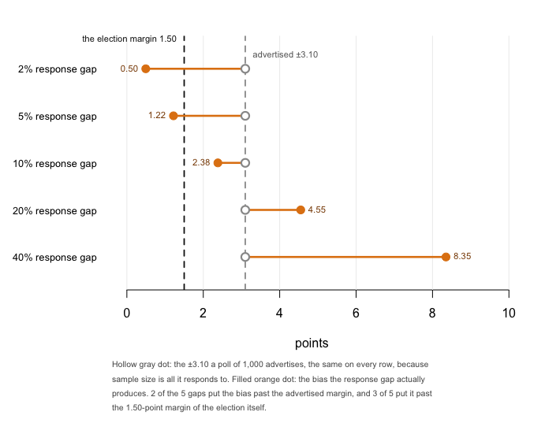

**Figure 3. What each response gap costs, against what the poll advertises.** One row per gap. The hollow gray dot is the ±3.10 a poll of 1,000 advertises, identical on every row because sample size is the only thing it responds to. The filled orange dot is the bias the gap actually produces. 2 of the 5 gaps put the bias past the advertised margin, and 3 of 5 put it past the 1.50-point margin of the election itself.

A 5% difference in willingness to answer produces 1.22 points of bias. No pollster could detect a gap that size, and it sounds like nothing. Measured against the 1.50-point election this simulation is built around, it is most of the answer. And that, not the advertised margin, is the right yardstick: the bias should be compared to the thing you are trying to detect.

Pollsters know all this, and they correct for it by **weighting**: counting some answers more than others, to fix a sample that does not look like the country. Build a population where answering the phone is driven by trust in institutions rather than by the vote itself, and try it.

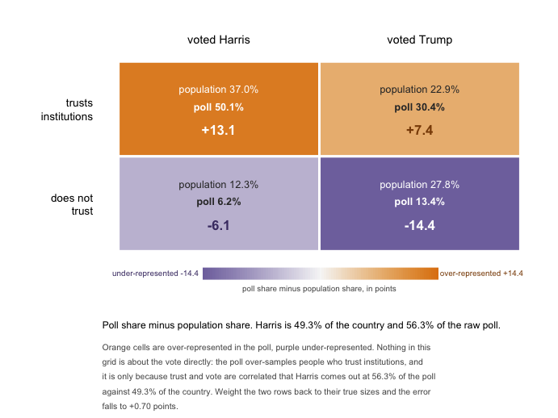

Orange cells are over-represented in the poll, purple under-represented. Nothing in this grid is about the vote directly: the poll over-samples people who trust institutions, and it is only because trust and vote are correlated that Harris comes out at 56.3% of the poll against 49.3% of the country. Weight the two rows back to their true sizes and the error falls to +0.70 points.

**Figure 4. Who the poll reached, and who it should have reached.** One cell per combination of vote and trust, shaded by the poll’s share of that cell minus the population’s: orange over-represented, purple under. Nothing in the grid is about the vote directly. The poll over-samples people who trust institutions, and only because trust and vote go together does Harris come out at 56.3% of the poll against 49.3% of the country.

| Estimate | Harris share (%) | Error (points) |
| --- | --- | --- |
| The truth | 49.28 | — |
| Raw poll | 56.26 | +6.98 |
| Weighted on trust | 49.98 | +0.70 |
| Weighted on a variable unrelated to response | 56.26 | +6.98 |

Weighting on the thing that actually drives non-response takes the error from +6.98 to +0.70. Weighting on a real, measurable, irrelevant variable moves it essentially not at all, to +6.98. **Weighting works exactly and only when you already know what is wrong.** After 2016 the industry discovered it had not been weighting by education and added it;[^3] in 2020 it missed again, in the same direction, and the review by AAPOR, the pollsters’ professional association, could not identify the mechanism.[^4] The variable you have not thought of is invisible by construction, and no amount of arithmetic finds it.

The record outside the simulation says the mechanism is real. Meng (2018) proves the formal version, the *big data paradox*: “the more the data, the surer we fool ourselves.”[^5] He computes that a self-selected sample of 2.3 million voters in 2016 carried the same error as a random sample of about 400. Bradley and colleagues (2021) watched it happen outside politics: a 250,000-response-per-week survey overstated vaccine uptake by up to 17 points while a small random sample was close.[^6] The margin of error, honest within its terms, describes the smallest problem a poll has — and for the states that decide elections, the problem it describes was never the one going wrong.

## What this brief cannot tell you

It is a simulation, and a simulation is not evidence about the world. The 20% response gap was invented to make the mechanism visible; nothing here says real polls are biased by 4.55 points, or that Harris voters really answered more often. Real non-response is many variables tangled together and shifting between elections, not one tidy dial. And a real gap’s size cannot be measured: a gap that could be measured would already have been weighted away.

The sampling here is independent draws, while real polls cluster, stratify and re-contact — draw people in geographic bunches, split the sample by known groups before drawing, and call back the ones who did not answer — all of which change the effective sample in ways the square-root rule does not capture. And the real 2024 file is thin: percentages and electoral votes, no counts, no archive of actual polls, so it shows how hard the task was rather than how any particular poll performed at it. Whether the polling industry is in crisis is genuinely disputed: three cycles erring in the same direction is a pattern, not a mechanism, and this brief settles none of that. It establishes something narrower: the quantity published as a poll’s uncertainty is not the quantity that has been going wrong.

## What you should have learned

- The margin of error covers sampling error only, and it is silent about everything else; the promise itself is kept exactly, with about 95% of honest polls inside ±3.10.
- A 20% response gap makes a poll of 100,000 people miss by 4.43 points while advertising ±0.31; bias responds to the gap and not to sample size, so the two numbers are not measuring the same thing.
- Past about 464 respondents, a biased poll’s own interval never contains the truth again; more data buys agreement, not accuracy.
- A gap of 5%, too small for any pollster to detect, produces 1.22 points of bias — most of a 1.50-point election.
- Weighting fixes only the imbalances you already know about, which is why the 2016 education failure could repeat in 2020.

## Extensions

- `pres2024_states.csv` holds the real result in every state, with `margin` and `ev`. Sort by `margin`. How many electoral votes sat inside a margin a normal poll could not resolve?
- Take the states with the smallest `margin` values in `pres2024_states.csv` and add their `ev` together. What is the smallest set of states a polling error would have to get wrong to change the outcome?
- Pick a state in `pres2024_states.csv` and imagine a poll off by three points in the same direction everywhere. Work down the `margin` column and count how many states flip.
- A margin of error covers sampling and nothing else. List three things that could go wrong in polling the states in `pres2024_states.csv` outside the sampling, and say which would be hardest to detect.
- **Stretch:** the Cooperative Election Study, the large online survey the weighting chapter is built on, publishes tens of thousands of real interviews per cycle with the weights attached. Download one year and compare its weighted and unweighted presidential vote shares: how much work are the weights doing?
- **Stretch:** read Meng (2018) and work out his effective-sample formula for a poll you have seen reported this year. What would its honest sample size be under a small response gap?

## Sources

**Data**

- `pres2024_states.csv` — 2024 presidential results by state, cut from Timm’s *PresElectionResults* compilation (https://github.com/jaytimm/PresElectionResults), which rests on the fifty-one separate state canvasses; electoral votes keyed in from the 2020 apportionment. Everything else in this document is simulated, from a stipulated population, and is evidence about mechanisms rather than about any real poll.

**Academic literature**

- Bailey, M. A. (2024). *Polling at a Crossroads: Rethinking Modern Survey Research*. Cambridge University Press.
- Bradley, V. C., Kuriwaki, S., Isakov, M., Sejdinović, D., Meng, X.-L. and Flaxman, S. (2021). “Unrepresentative big surveys significantly overestimated US vaccine uptake.” *Nature* 600: 695–700. https://www.nature.com/articles/s41586-021-04198-4
- Groves, R. M. (2006). “Nonresponse Rates and Nonresponse Bias in Household Surveys.” *Public Opinion Quarterly* 70(5): 646–675. doi:10.1093/poq/nfl033
- Kennedy, C. et al. (2018). “An Evaluation of the 2016 Election Polls in the United States.” *Public Opinion Quarterly* 82(1): 1–33. doi:10.1093/poq/nfx047. The same task force’s full report: https://aapor.org/wp-content/uploads/2022/11/AAPOR-2016-Election-Polling-Report.pdf
- Meng, X.-L. (2018). “Statistical paradises and paradoxes in big data (I): Law of large populations, big data paradox, and the 2016 US presidential election.” *Annals of Applied Statistics* 12(2): 685–726. https://doi.org/10.1214/18-AOAS1161SF
- AAPOR Task Force on 2020 Pre-Election Polling (2021). *An Evaluation of the 2020 General Election Polls*. American Association for Public Opinion Research. https://aapor.org/; the report itself: https://aapor.org/wp-content/uploads/2022/11/AAPOR-Task-Force-on-2020-Pre-Election-Polling_Report-FNL.pdf
- Pew Research Center (2019). “Response rates in telephone surveys have resumed their decline.” https://www.pewresearch.org/methods/2019/02/27/response-rates-in-telephone-surveys-have-resumed-their-decline/
- U.S. Census Bureau. *2020 Census Apportionment Results.* https://www.census.gov/data/tables/2020/dec/2020-apportionment-data.html

**The data itself**

Every figure above is drawn from these tables. They are plain CSV, they open in a spreadsheet, and they are yours to take further.

`pres2024_states.csv`

[^1]: The Census Bureau’s 2020 apportionment results: https://www.census.gov/data/tables/2020/dec/2020-apportionment-data.html.
[^2]: Pew Research Center, “Response rates in telephone surveys have resumed their decline,” 27 February 2019, https://www.pewresearch.org/methods/2019/02/27/response-rates-in-telephone-surveys-have-resumed-their-decline/.
[^3]: American Association for Public Opinion Research, *An Evaluation of the 2016 Election Polls in the United States* (2017), https://aapor.org/wp-content/uploads/2022/11/AAPOR-2016-Election-Polling-Report.pdf.
[^4]: AAPOR Task Force on 2020 Pre-Election Polling, *An Evaluation of the 2020 General Election Polls* (2021), https://aapor.org/wp-content/uploads/2022/11/AAPOR-Task-Force-on-2020-Pre-Election-Polling_Report-FNL.pdf.
[^5]: Xiao-Li Meng, “Statistical paradises and paradoxes in big data (I): Law of large populations, big data paradox, and the 2016 US presidential election,” *Annals of Applied Statistics* 12, no. 2 (2018): 685–726, https://doi.org/10.1214/18-AOAS1161SF.
[^6]: Valerie C. Bradley et al., “Unrepresentative big surveys significantly overestimated US vaccine uptake,” *Nature* 600 (2021): 695–700, https://www.nature.com/articles/s41586-021-04198-4.